# IU Fingerprinting Vignette

Lily Koffman

2023-02-28

### Data Summary

Summary of Times by Session and Recording

| Subject | Number Seconds | Minutes |
| --- | --- | --- |
| 1 | 478 | 7.97 |
| 2 | 491 | 8.18 |
| 3 | 521 | 8.68 |
| 4 | 585 | 9.75 |
| 5 | 546 | 9.10 |
| 6 | 500 | 8.33 |
| 7 | 520 | 8.67 |
| 8 | 430 | 7.17 |
| 9 | 463 | 7.72 |
| 10 | 523 | 8.72 |
| 11 | 475 | 7.92 |
| 12 | 551 | 9.18 |
| 13 | 453 | 7.55 |
| 14 | 551 | 9.18 |
| 15 | 456 | 7.60 |
| 16 | 502 | 8.37 |

Summary of Times by Session and Recording

| Subject | Number Seconds | Minutes |
| --- | --- | --- |
| 17 | 518 | 8.63 |
| 18 | 453 | 7.55 |
| 19 | 448 | 7.47 |
| 20 | 460 | 7.67 |
| 21 | 488 | 8.13 |
| 22 | 450 | 7.50 |
| 23 | 424 | 7.07 |
| 24 | 426 | 7.10 |
| 25 | 509 | 8.48 |
| 26 | 441 | 7.35 |
| 27 | 520 | 8.67 |
| 28 | 514 | 8.57 |
| 29 | 574 | 9.57 |
| 30 | 450 | 7.50 |
| 31 | 383 | 6.38 |
| 32 | 502 | 8.37 |

### Data Visualization

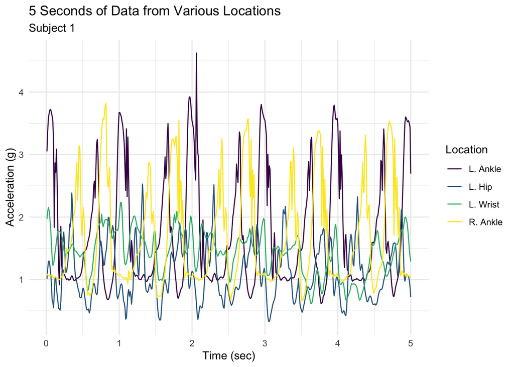

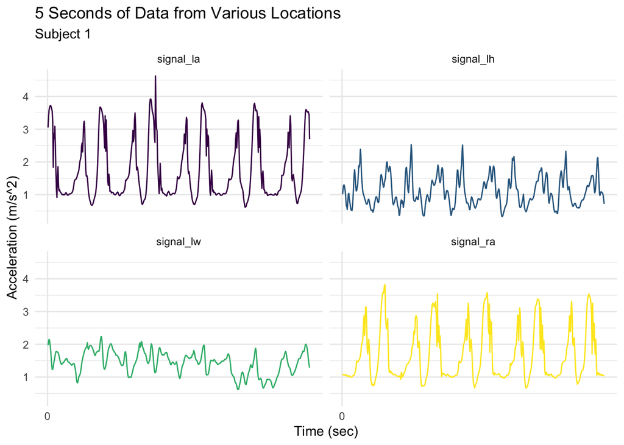

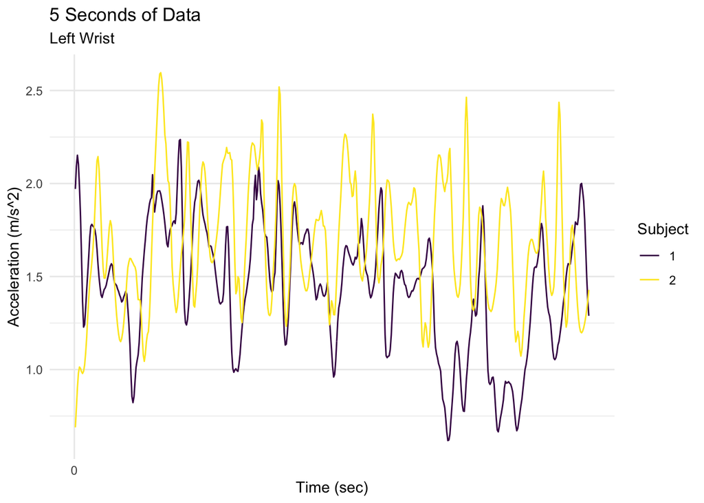

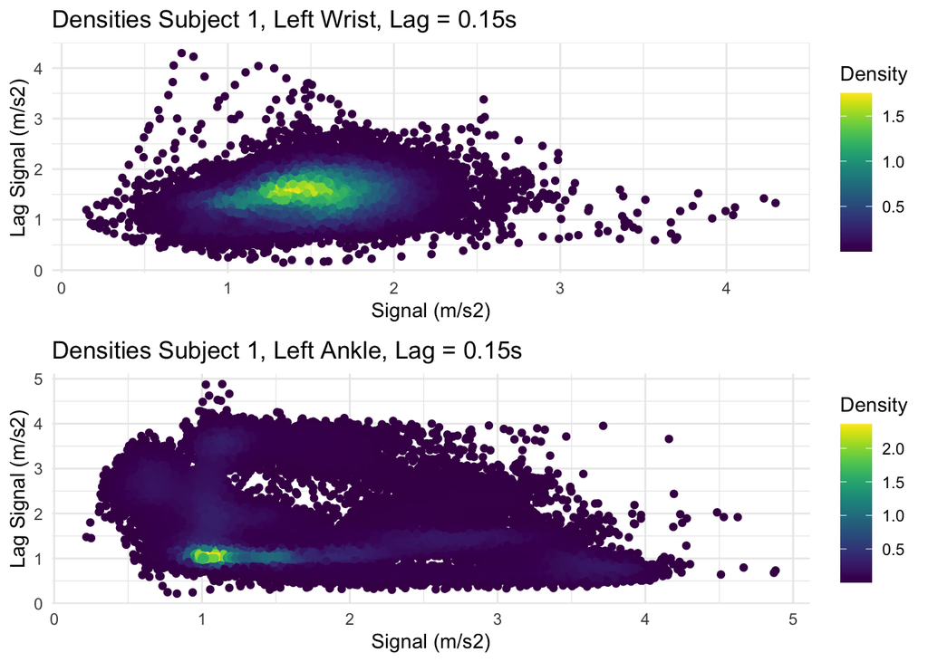

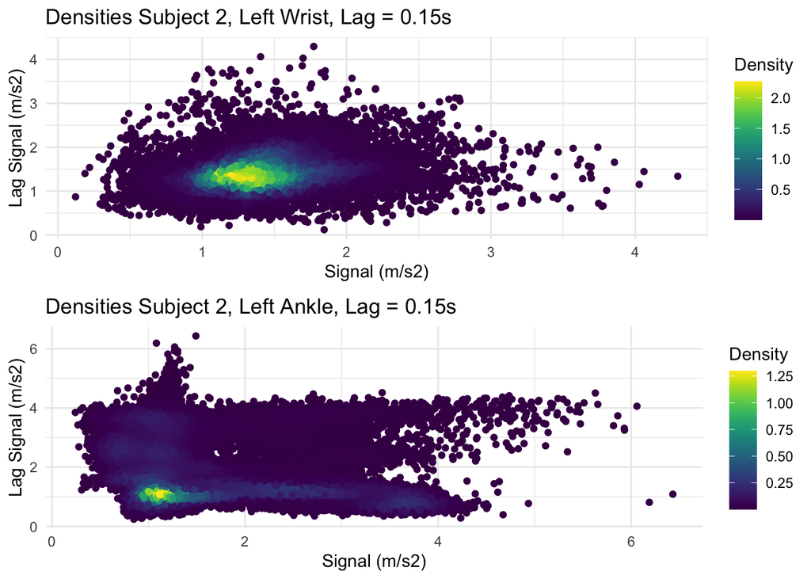

### Model Fitting

We calculate the grid cell predictors using time lags of 0.15, 0.30, 0.45, 0.60, 0.75, and 0.90 seconds and grid cell size of 0.25 m/s2. We split the data into 50% training and 50% testing. We filter the training data to the grid cells with at least 0.1% of the data; we use these grid cells as predictors in a logistic regression. We use one vs. rest logistic regression to obtain predicted probabilities for each subject on the testing data. Then we calculate the average probability for each subject and determine whether the model has identified the correct individual. Finally, we plot the predicted probabilities, calculate the overall AUC, and plot each individual AUC curve.

### Left Wrist Results

Incorrect Subjects Summary

Correct prediction rate: 1

| Subject | Highest Predicted Probability | Predicted Subject | True Subject Predicted Probability |
| --- | --- | --- | --- |

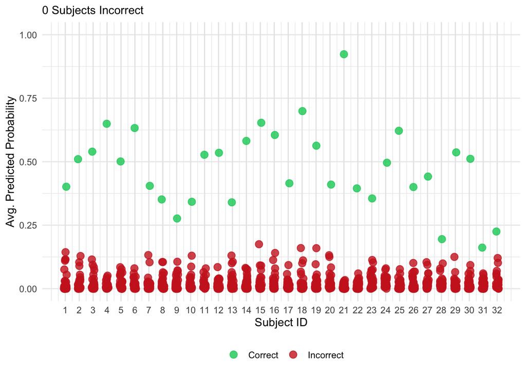

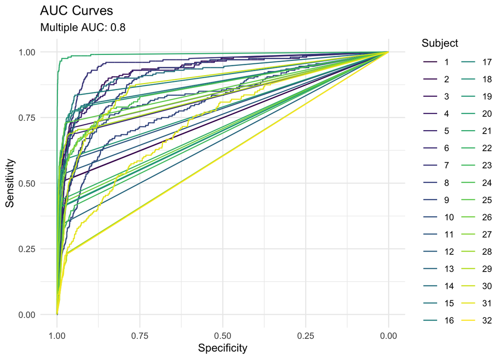

### Distance Metrics

We’re interested in looking at a ``distance” between two subjects’ data. We consider the Hamming distance, which is the number of bit positions in which the two bits are different between two vectors. For example,

$$a = \{1, 2, 0, 0, 7\}$$
$$b = \{1, 3, 4, 0, 0\}$$
Then Hamming distance$(a,b) = 3$.

In this application, we have two sets of vectors that we’re interested in comparing. I consider two ways to calculate the Hamming distance between two sets of vectors. Let the training data for subject 1 be represented as follows, where we have $k$ predictors and $j$ rows of data.
$$X_{1, train}= \begin{bmatrix} x_{11}& x_{12}
&\dots& x_{1 k} \\
\vdots & \vdots & \vdots & \vdots \\
x_{j 1} & x_{j2} & \dots & x_{jk}
\end{bmatrix}$$

Then we can take the mean of each column and round to the nearest integer to get a “summary” vector for the training data, and do the same for the testing data.
$$\overline{X}_{1,
train} = \Big[\big\lfloor\frac{1}{j}\sum_{i=1}^jx_{i1}\big\rfloor,
\big\lfloor\frac{1}{j}\sum_{i=1}^jx_{i2}\big\rfloor,
\dots, \big\lfloor\frac{1}{j}\sum_{i=1}^j x_{ik}\big\rfloor\Big]$$

Then we would calculate Hamming($\overline{X}_{1, train},\overline{X}_{1, test}$, Hamming($\overline{X}_{1, train},\overline{X}_{2, test}$, and so on for all pairwise combinations of training subjects and testing subjects. In total, there are $32*32 = 1024$ pairs to test.

We could instead take the median of each column to get the “summary” vector and calculate the Hamming distances as above with each pairwise combination.

$$\widetilde{X}_{1, train} =
\Big[med(x_{11}, x_{21}, \dots, x_{j1}), med(x_{12}, x_{22}, \dots,
x_{j2}),\dots, med(x_{1k}, x_{2k}, \dots, x_{jk})\Big]$$

### Mean Method

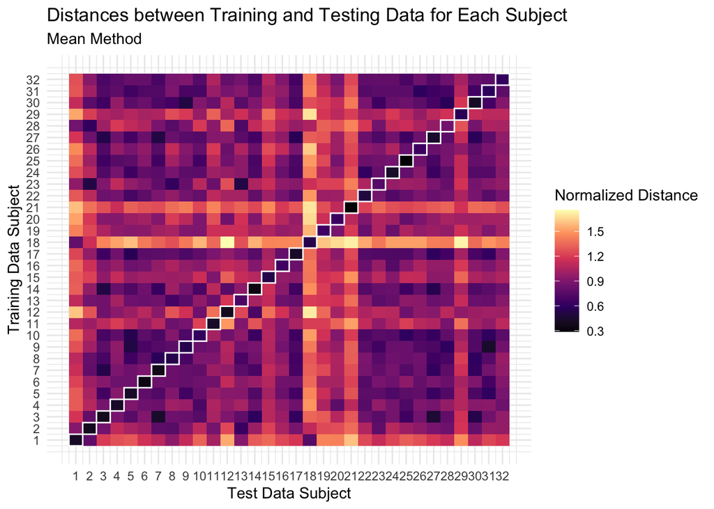

### Median Method

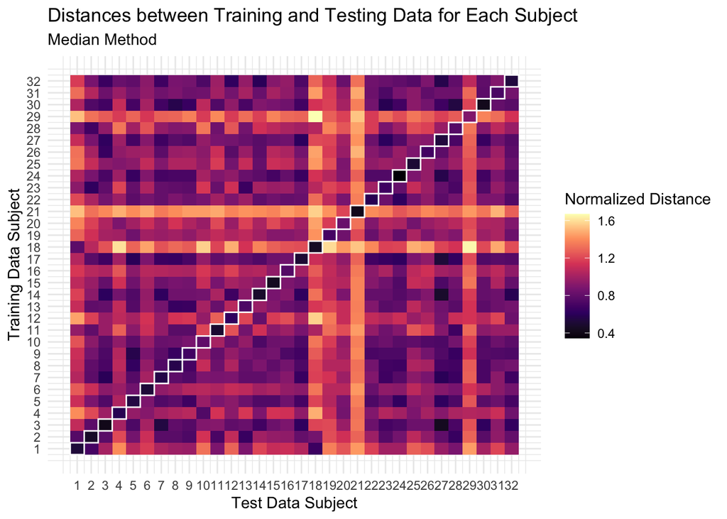

### A Different Approach to Distances

We can think of our data as a 3D image, like these:

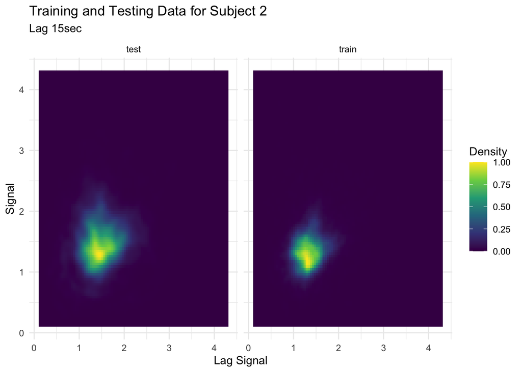

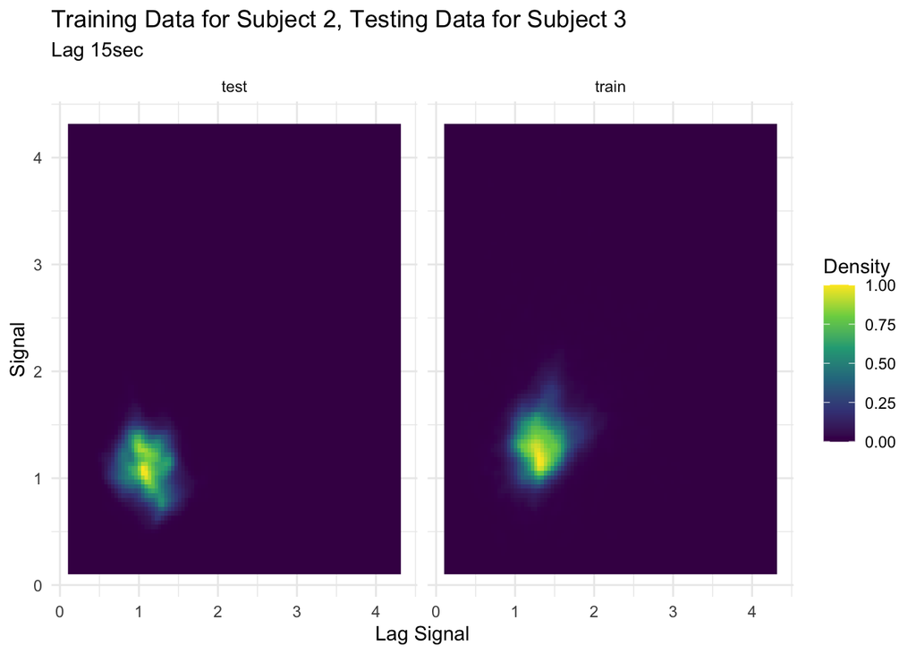

We could represent these images as matrices, where entry $x_{ij} = \text{density or number of points}$ where signal is in interval $i$ and lag signal is in interval $j$. Using intervals of 0.25 $m/s^2$, this would result in a 12x12 matrix for each a given lag. For example, the matrix for subject 2, training data, lag 0.15 second is below:

```
## # A tibble: 12 × 12
##    `[0,0.25]` (0.25,0.…¹ (0.5,…² (0.75…³ (1,1.…⁴ (1.25…⁵ (1.5,…⁶ (1.75…⁷ (2,2.…⁸
##         <dbl>      <dbl>   <dbl>   <dbl>   <dbl>   <dbl>   <dbl>   <dbl>   <dbl>
##  1          0          0       0       0       0       1       1       0       0
##  2          0          0       0       0       2       5       2       1       2
##  3          0          0       0      12      70      64      24       6       3
##  4          1          3      13     139     432     422      68      11       1
##  5          1          6      64     325    1637    2299     651      91      13
##  6          0          5      43     497    2138    2003    1107     454     100
##  7          0          3      19     125     729     978     491     256      84
##  8          0          0      10      37     105     439     229      77      34
##  9          0          1       7       9      25     101      82      38      18
## 10          0          1       3      12      17      14      15      19      10
## 11          0          0       0       7      11       3      10       5       7
## 12          0          0       3       3       2       7       1       2       3
## # … with 3 more variables: `(2.25,2.5]` <dbl>, `(2.5,2.75]` <dbl>,
## #   `(2.75,3]` <dbl>, and abbreviated variable names ¹`(0.25,0.5]`,
## #   ²`(0.5,0.75]`, ³`(0.75,1]`, ⁴`(1,1.25]`, ⁵`(1.25,1.5]`, ⁶`(1.5,1.75]`,
## #   ⁷`(1.75,2]`, ⁸`(2,2.25]`
```

For each subject, we can calculate the matrix of the image for all of the lags, in the training and the testing data, then we can compute the squared Frobenius distance between all combinations of training and testing data.

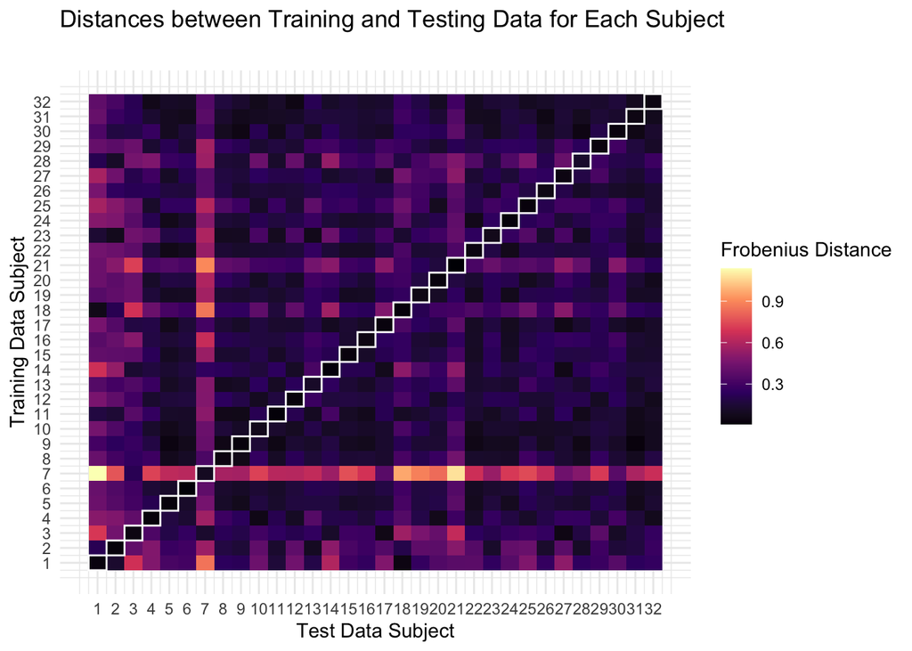

### Comparing “Distances” and Predictive Performance

We can look at which subjects are the best predicted:

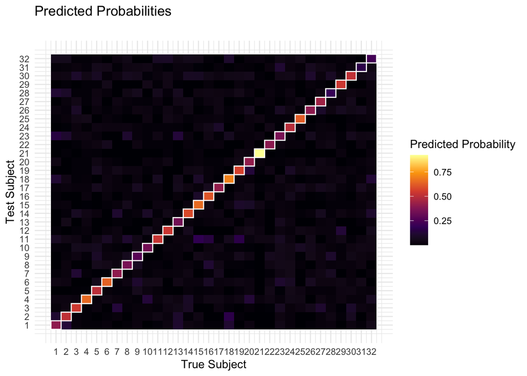

For each subject, we can also look at the difference between the correct probability and the second highest probability:

Prediction Summary

| Subject | Dist Next Highest Prob | Dist Mean Other Probs |
| --- | --- | --- |
| 21 | 0.89 | 0.92 |
| 4 | 0.60 | 0.64 |
| 6 | 0.55 | 0.62 |
| 25 | 0.54 | 0.61 |
| 18 | 0.54 | 0.68 |
| 14 | 0.50 | 0.56 |
| 15 | 0.48 | 0.63 |
| 16 | 0.46 | 0.58 |
| 12 | 0.45 | 0.52 |
| 11 | 0.45 | 0.51 |
| 3 | 0.42 | 0.52 |
| 30 | 0.42 | 0.49 |
| 5 | 0.42 | 0.48 |
| 24 | 0.42 | 0.47 |
| 29 | 0.41 | 0.52 |
| 19 | 0.40 | 0.54 |

Prediction Summary

| Subject | Dist Next Highest Prob | Dist Mean Other Probs |
| --- | --- | --- |
| 2 | 0.38 | 0.49 |
| 27 | 0.34 | 0.42 |
| 22 | 0.33 | 0.38 |
| 17 | 0.32 | 0.40 |
| 26 | 0.30 | 0.38 |
| 20 | 0.28 | 0.38 |
| 7 | 0.27 | 0.39 |
| 1 | 0.26 | 0.38 |
| 8 | 0.25 | 0.33 |
| 23 | 0.24 | 0.32 |
| 10 | 0.21 | 0.32 |
| 13 | 0.21 | 0.31 |
| 9 | 0.17 | 0.25 |
| 32 | 0.10 | 0.20 |
| 31 | 0.10 | 0.14 |
| 28 | 0.10 | 0.17 |